# peergraded2

abelismyid

27 June 2017

# 1. Load the ToothGrowth data and perform some basic exploratory data analyses

We will use ggplot2 library and ToothGrowth data.

```r
library(ggplot2)
data("ToothGrowth")
```

# 2. Provide a basic summary of the data.

```r
summary(ToothGrowth)
```

```
##       len        supp         dose
##  Min.   : 4.20   OJ:30   Min.   :0.500
##  1st Qu.:13.07   VC:30   1st Qu.:0.500
##  Median :19.25           Median :1.000
##  Mean   :18.81           Mean   :1.167
##  3rd Qu.:25.27           3rd Qu.:2.000
##  Max.   :33.90           Max.   :2.000
```

```r
str(ToothGrowth)
```

```
## 'data.frame':    60 obs. of  3 variables:
##  $ len : num  4.2 11.5 7.3 5.8 6.4 10 11.2 11.2 5.2 7 ...
##  $ supp: Factor w/ 2 levels "OJ","VC": 2 2 2 2 2 2 2 2 2 2 ...
##  $ dose: num  0.5 0.5 0.5 0.5 0.5 0.5 0.5 0.5 0.5 0.5 ...
```

# 3. Use confidence intervals and/or hypothesis tests to compare tooth growth by supp and dose. (Only use the techniques from class, even if there’s other approaches worth considering)

We will first observe the datas and find correlations. The lines represent the means of each group.

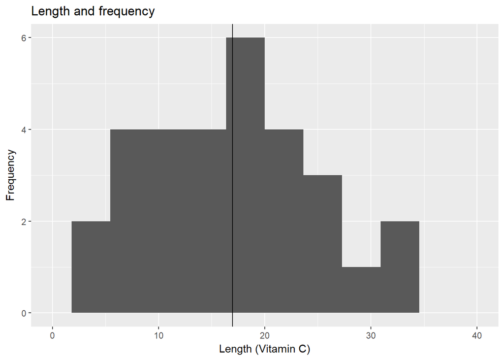

```r
hist1 <- ggplot (aes(x=len), data = ToothGrowth[ToothGrowth$supp == "VC",]) +
  ggtitle ("Length and frequency") +labs(x="Length (Vitamin C)", y="Frequency") +geom_histogram(bins = 12) + xlim(0, 40) + geom_vline(aes(xintercept = mean(ToothGrowth[ToothGrowth$supp == "VC",]$len) ))

hist2 <- ggplot (aes(x=len), data = ToothGrowth[ToothGrowth$supp == "OJ",]) +
  labs(x="Length (Orange Juice)", y="Frequency ") + geom_histogram(bins = 12) + xlim(0, 40)  + scale_y_reverse() + geom_vline(aes(xintercept = mean(ToothGrowth[ToothGrowth$supp == "OJ",]$len) ))

hist1
```

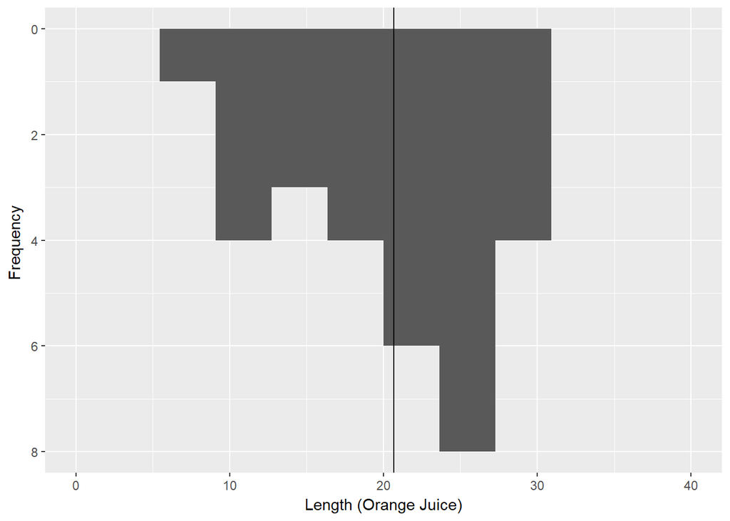

```r
hist2
```

We also have another possible correlation.

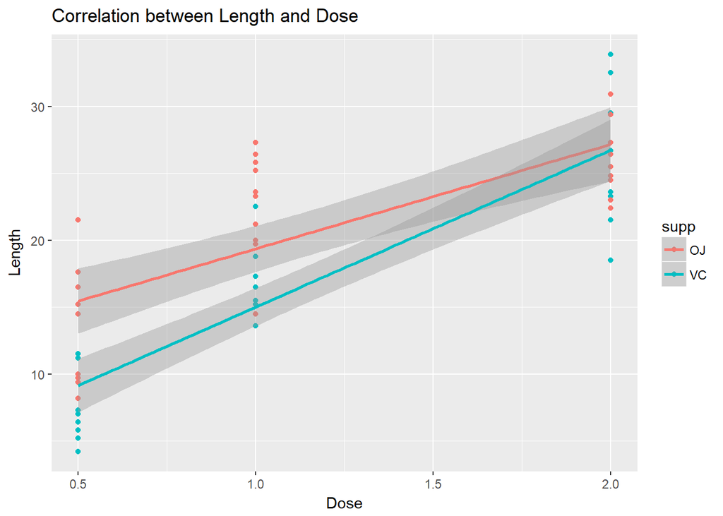

# 4. State your conclusions and the assumptions needed for your conclusions.

Suppose there is no correlation between dose and there is no difference between orange juice and vitamin C group. We will test if this hypothesis is true or not.

Assuming the guinea pigs were randomly selected independently, we can use same variance to compare the results.

```r
VCgroup<-ToothGrowth[ToothGrowth$supp=="VC","len"]
OJgroup<-ToothGrowth[ToothGrowth$supp=="OJ","len"]

t.test(VCgroup,OJgroup,paired=FALSE,var.equal=TRUE)$conf
```

```
## [1] -7.5670064  0.1670064
## attr(,"conf.level")
## [1] 0.95
```

Since 0 is contained inside the 95 percent confidence interval of the t-test, we cannot reject the hypothesis that there is no difference between injecting Vitamin C and feeding orange juice.

Now, we will see the effect of the amount of dosage.

```r
d05<-ToothGrowth[ToothGrowth$dose==0.5,"len"]
d10<-ToothGrowth[ToothGrowth$dose==1.0,"len"]
d20<-ToothGrowth[ToothGrowth$dose==2.0,"len"]

t.test(d05,d10,paired=FALSE,var.equal=TRUE)$conf
```

```
## [1] -11.983748  -6.276252
## attr(,"conf.level")
## [1] 0.95
```

```r
t.test(d10,d20,paired=FALSE,var.equal=TRUE)$conf
```

```
## [1] -8.994387 -3.735613
## attr(,"conf.level")
## [1] 0.95
```

Since the 95 perent confidence interval does not have 0, we can reject the hypothesis that the amount of the dosage does not impact on the tooth growth.